# Regresja i analiza wariancji - Laboratorium 11

Redukcja wymiarowości

Adrian Kowalski

Politechnika Krakowska

```r
library(tidyverse)
library(MASS)
library(ggfortify)
library(VGAM)
library(caret)
library(e1071)
```

```r
wine <- readr::read_csv('Wine.csv') %>% dplyr::mutate(Customer_Segment = as.factor(Customer_Segment))
head(wine)
```

| Alcohol | Malic_Acid | Ash | Ash_Alcanity | Magnesium | Total_Phenols | Flavanoids | Nonflavanoid_Phenols | Proanthocyanins | Color_Intensity | Hue | OD280 | Proline | Customer_Segment |
| --- | --- | --- | --- | --- | --- | --- | --- | --- | --- | --- | --- | --- | --- |
| 14.23 | 1.71 | 2.43 | 15.6 | 127 | 2.80 | 3.06 | 0.28 | 2.29 | 5.64 | 1.04 | 3.92 | 1065 | 1 |
| 13.20 | 1.78 | 2.14 | 11.2 | 100 | 2.65 | 2.76 | 0.26 | 1.28 | 4.38 | 1.05 | 3.40 | 1050 | 1 |
| 13.16 | 2.36 | 2.67 | 18.6 | 101 | 2.80 | 3.24 | 0.30 | 2.81 | 5.68 | 1.03 | 3.17 | 1185 | 1 |
| 14.37 | 1.95 | 2.50 | 16.8 | 113 | 3.85 | 3.49 | 0.24 | 2.18 | 7.80 | 0.86 | 3.45 | 1480 | 1 |
| 13.24 | 2.59 | 2.87 | 21.0 | 118 | 2.80 | 2.69 | 0.39 | 1.82 | 4.32 | 1.04 | 2.93 | 735 | 1 |
| 14.20 | 1.76 | 2.45 | 15.2 | 112 | 3.27 | 3.39 | 0.34 | 1.97 | 6.75 | 1.05 | 2.85 | 1450 | 1 |

# Po co redukować wymiary?

Na sam początek należy zadać pytanie: “Po co redukować wymiary w danych?”. Odpowiedzi nasuwa się kilka. Byćmoże najbardziej oczywistą jest fakt, że mamy bardzo ograniczone możliwości wizualizacji danych, jeżeli rozważamy więcej niż 3 cechy (a już dla 3 wizualizacja robi się problematyczna). Jeżeli bylibyśmy w stanie znaleźć algorytmy, które sprowadzą nasze dane do przestrzeni $2$-wymiarowej i zachowują zależności między nimi (chociażby relatywne odległości), to przy odpowiedniej interpretacji taka wizualizacja byłaby korzystna.

Druga odpowiedź, na którą nie trudno wpaść, wiąże się z powiedzeniem, że “w $R^n$ wszystko jest daleko od siebie” (dla dużych $n$). Zjawisko to zwane jest “klątwą wymiarowości” (chcemy mieć jak najwięcej cech, aby dokładnie badać zależności, ale natykamy się na problem ze zbieżnością). Zatem, gdy mamy dużą przestrzeń cech, odległości między punktami będą bardzo duże, przez co algorytmy bazujące na odległościach (większość z poznanych przez nas) będą miały problemy ze zbieżnością. Korzystnym rozwiązaniem byłoby zatem sprowadzić jakoś nasze dane do przestrzeni o zdecydowanie mniejszej ilości wymiarów, zachowując jednak przy tym strukturę zależności między punktami.

Algorytmy, o których mowa oczywiście istnieją i zajmiemy się dziś podstawowymi dwoma.

# Redukcja wymiarowości przy pomocy LDA

Na poprzednich zajęciach poznaliśmy algorytm LDA, którego używaliśmy do klasyfikacji. Okazuje się, że nie jest to jedyne zastoswanie tego algorytmu. Za pomocą LDA możemy też dokonywać redukcji wymiarowości. W tej sytuacji jest to algorytm uczenia nadzorowanego, wymagamy do uczenia danych z etykietami. Dzięki temu, algorytm LDA znajduje projekcję na $K-1$ wymiarową przestrzeń (gdzie $K$ to liczba klas), w której nasze dane są “najlepiej” rozdzielone.

```r
index <- caret::createDataPartition(wine$Customer_Segment, list = FALSE)
wine_train <- wine[index,]
wine_test <- wine[-index,]
```

```r
lda_1 <- MASS::lda(Customer_Segment ~. , data = wine_train)
wine_train_transform <- as.data.frame(predict(lda_1, wine_train))
wine_test_transform <- as.data.frame(predict(lda_1, wine_test))
head(wine_test_transform)
```

|  | class | posterior.1 | posterior.2 | posterior.3 | x.LD1 | x.LD2 |
| --- | --- | --- | --- | --- | --- | --- |
| 1 | 1 | 1.0000000 | 5.304033e-10 | 1.884654e-17 | -4.663008 | 1.3740461 |
| 2 | 1 | 0.9999980 | 2.000109e-06 | 8.094607e-14 | -3.534396 | 0.5956118 |
| 3 | 1 | 0.9688632 | 3.113640e-02 | 3.755639e-07 | -1.578479 | 0.3444259 |
| 4 | 1 | 1.0000000 | 1.225300e-12 | 1.474043e-18 | -5.084708 | 2.3813545 |
| 5 | 1 | 1.0000000 | 1.501901e-08 | 9.718356e-14 | -3.620635 | 1.6752480 |
| 6 | 1 | 1.0000000 | 3.062930e-10 | 1.972211e-14 | -3.886596 | 2.3258552 |

```r
lda_1$scaling
```

```
                              LD1           LD2
Alcohol              -0.623416948  1.0767841131
Malic_Acid           -0.110477417  0.1416046469
Ash                  -0.257451778  3.4203705534
Ash_Alcanity          0.124513392 -0.1822684658
Magnesium            -0.008852572 -0.0007392147
Total_Phenols         0.269204219 -0.1040696474
Flavanoids           -1.437979939 -0.7637697008
Nonflavanoid_Phenols -1.459955408 -2.8586697701
Proanthocyanins       0.070702879 -0.4549559331
Color_Intensity       0.412218763  0.2364864031
Hue                  -1.076953022 -2.9990519523
OD280                -0.892453307 -0.1834702913
Proline              -0.003782341  0.0020212914
```

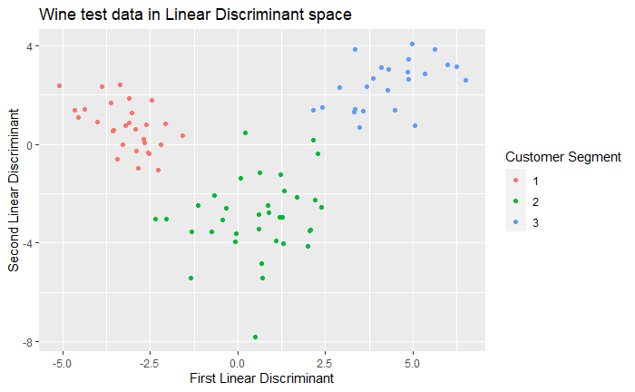

```r
ggplot(data = wine_test_transform, aes(x = x.LD1, y = x.LD2, color = wine_test$Customer_Segment)) + geom_point() + labs(x = 'First Linear Discriminant', y = 'Second Linear Discriminant', color = 'Customer Segment', title = 'Wine test data in Linear Discriminant space')
```

# Analiza składowych głównych PCA

Innym algorytmem redukcji wymiarowości jest analiza składowych głównych PCA. Stosuje ona nieco inne podejście, przez co nie wymaga danych etykietowanych. W wypadku tego algorytmu nie będziemy projektowali na przestrzeń, która najlepiej rozdziela nasze dane pod względem klas. Otrzymamy jednak projekcję na przestrzeń, w której zachowana jest jak największa część całkowitej wariancji zawartej w danych.

Algorytm PCA przebiega następująco:

- Standaryzujemy naszą macierz danych $X$, tak aby każda kolumna miała średnią $0$ i wariancję $1$,
- Wyznaczamy macierz korelacj $XX^T$,
- Wyznaczamy wektory i wartości własne macierzy $XX^T$,
- Spośród wartości własnych wybieramy $k$ największych,
- Dokonujemy projekcji na podprzestrzeń rozpiętą na odpowiadających im wektorach własnych.

```r
PCA_wine <- prcomp(wine_train[-14], scale = TRUE, center = TRUE)
PCA_wine
```

```
Standard deviations (1, .., p=13):
 [1] 2.2235968 1.6255880 1.2082648 1.0029569 0.8825796 0.7224814 0.6294422 0.6092831 0.4948399 0.4868921
[11] 0.4294043 0.3556594 0.2934159

Rotation (n x k) = (13 x 13):
                             PC1          PC2         PC3         PC4          PC5         PC6         PC7
Alcohol              -0.21676691  0.421910766 -0.23627484  0.12434397 -0.147388668  0.19796656 -0.36907692
Malic_Acid            0.21709403  0.188254205  0.31874723  0.57217858 -0.094618954  0.49040896 -0.13222032
Ash                   0.01783811  0.314017168  0.55073651 -0.41011676 -0.205505448  0.11539838 -0.03354695
Ash_Alcanity          0.29960780 -0.031765127  0.47881426 -0.18430552  0.005072506 -0.33488320 -0.34610633
Magnesium            -0.11957929  0.424343486  0.15694003 -0.28067692  0.457602878  0.19770398  0.15742644
Total_Phenols        -0.39454904 -0.009970826  0.18826763  0.06952681 -0.037109281 -0.08337523  0.46317433
Flavanoids           -0.40488865 -0.071117033  0.23867403  0.01529018 -0.065437206 -0.13979165  0.17277747
Nonflavanoid_Phenols  0.29512592  0.011659229 -0.06349737 -0.15070847 -0.733092369  0.11871859  0.39907576
Proanthocyanins      -0.31953544 -0.044144941  0.24256821  0.34782748 -0.273419318 -0.39671856 -0.29782948
Color_Intensity      -0.01202783  0.532738225 -0.15290458  0.11721787 -0.091999058 -0.44484441  0.14345785
Hue                  -0.28133198 -0.258060017 -0.14125407 -0.42400837 -0.206551097  0.17754294 -0.39742986
OD280                -0.32606096 -0.255953772  0.24857186  0.12567811 -0.005844909  0.33924998  0.11983073
Proline              -0.32723992  0.289325725 -0.15801485 -0.13462373 -0.220595112  0.11526680 -0.12395772
                             PC8         PC9        PC10          PC11          PC12        PC13
Alcohol               0.15447760 -0.43198817  0.31614464 -0.3182461333 -0.3061802216 -0.03365660
Malic_Acid           -0.18408073  0.41205996  0.05789432  0.0106056178 -0.0242705141  0.11736302
Ash                   0.28836932 -0.01328967 -0.31035975 -0.3572047615  0.2555377341  0.01850534
Ash_Alcanity          0.08713499  0.01466575  0.41936932  0.3063009926 -0.3515755403 -0.11370387
Magnesium            -0.58558981 -0.19342509  0.06183707  0.1941098498  0.0009050302 -0.08438830
Total_Phenols         0.03774294  0.32227753  0.12122188 -0.2768589132 -0.4182247656 -0.45776531
Flavanoids           -0.05399516 -0.03994692  0.14288438 -0.0007506106 -0.1687974030  0.81652457
Nonflavanoid_Phenols -0.28517968 -0.23087341  0.12730617  0.1329283315 -0.0788421428 -0.02273630
Proanthocyanins      -0.41062661 -0.23705915 -0.31336681  0.0257969015  0.1545133891 -0.21846974
Color_Intensity       0.07338560  0.27351734  0.37812433  0.0543800204  0.4748567616  0.01932938
Hue                  -0.32610804  0.41460031  0.28952099 -0.1556042281  0.1879486497 -0.02804540
OD280                 0.30138905 -0.28793144  0.35439584  0.3324422149  0.4153905515 -0.19672676
Proline               0.22745821  0.24742684 -0.34463032  0.6378387059 -0.2233852346 -0.01821400
```

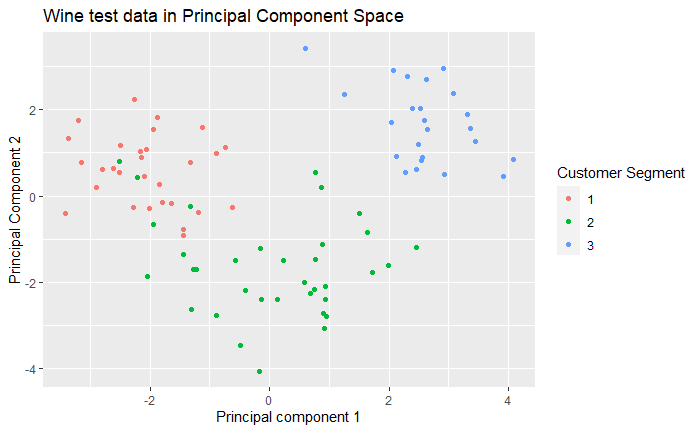

```r
PCA_wine_train_fits <- predict(PCA_wine, wine_train)
PCA_wine_fits <- predict(PCA_wine, wine_test)
ggplot(PCA_wine_fits, aes(x = PC1, y = PC2, color = wine_test$Customer_Segment)) + geom_point() + labs(title = 'Wine test data in Principal Component Space', x = 'Principal component 1', y = 'Principal Component 2', color = 'Customer Segment')
```

Ważnym narzędziem do diagnozowania jaką część wariancji z danych wyjaśniamy biorąć odpowiednią ilość składowych głównych jest tzw. “scree plot”. Tworzymy go następująco.

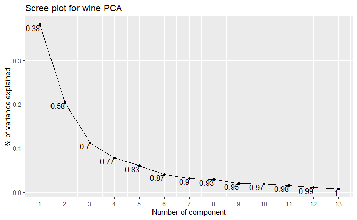

```r
variance_data <- sum(PCA_wine$sdev^2)
screes <- PCA_wine$sdev^2 / variance_data
pct_screes <- round(cumsum(screes),2)
screes <- cbind(c(1:length(screes)),screes)
colnames(screes) <- c('component', 'scree')
ggplot(screes, aes(x = component, y = scree, label = pct_screes)) + geom_point() + geom_line() + geom_text(vjust = 1, hjust = 1) + scale_y_continuous(breaks = seq(from = 0, to = 1, by = 0.1)) + scale_x_continuous(breaks = 1:13, labels = 1:13) + labs(title = 'Scree plot for wine PCA', x = 'Number of component', y = '% of variance explained')
```

# Modele na danych o zredukowanym wymiarze

Po przejściu do przestrzeni o zredukowanym wymiarze możemy oczywiście dopasować model do naszych danych, w celu chociażby klasyfikacji. Zastosujemy tutaj model klasy SVM i porównamy jego wyniki na danych bez redukcji wymiaru, z redukcją LDA i z redukcją PCA.

```r
baseline <- e1071::svm(Customer_Segment ~. , data = wine_train, kernel = 'linear', type = 'C')
confusionMatrix(data = predict(baseline, wine_test), reference = wine_test$Customer_Segment)
```

```
Confusion Matrix and Statistics

          Reference
Prediction  1  2  3
         1 29  2  0
         2  0 32  0
         3  0  1 24

Overall Statistics

               Accuracy : 0.9659
                 95% CI : (0.9036, 0.9929)
    No Information Rate : 0.3977
    P-Value [Acc > NIR] : < 2.2e-16

                  Kappa : 0.9485

 Mcnemar's Test P-Value : NA

Statistics by Class:

                     Class: 1 Class: 2 Class: 3
Sensitivity            1.0000   0.9143   1.0000
Specificity            0.9661   1.0000   0.9844
Pos Pred Value         0.9355   1.0000   0.9600
Neg Pred Value         1.0000   0.9464   1.0000
Prevalence             0.3295   0.3977   0.2727
Detection Rate         0.3295   0.3636   0.2727
Detection Prevalence   0.3523   0.3636   0.2841
Balanced Accuracy      0.9831   0.9571   0.9922
```

```r
baseline <- e1071::svm(Customer_Segment ~ Alcohol + Flavanoids , data = wine_train, kernel = 'linear', type = 'C')
confusionMatrix(data = predict(baseline, wine_test), reference = wine_test$Customer_Segment)
```

```
Confusion Matrix and Statistics

          Reference
Prediction  1  2  3
         1 28  2  0
         2  1 29  0
         3  0  4 24

Overall Statistics

               Accuracy : 0.9205
                 95% CI : (0.843, 0.9674)
    No Information Rate : 0.3977
    P-Value [Acc > NIR] : < 2.2e-16

                  Kappa : 0.8804

 Mcnemar's Test P-Value : NA

Statistics by Class:

                     Class: 1 Class: 2 Class: 3
Sensitivity            0.9655   0.8286   1.0000
Specificity            0.9661   0.9811   0.9375
Pos Pred Value         0.9333   0.9667   0.8571
Neg Pred Value         0.9828   0.8966   1.0000
Prevalence             0.3295   0.3977   0.2727
Detection Rate         0.3182   0.3295   0.2727
Detection Prevalence   0.3409   0.3409   0.3182
Balanced Accuracy      0.9658   0.9049   0.9688
```

```r
lda_svm <- e1071::svm(wine_train$Customer_Segment ~ wine_train_transform$x.LD1 + wine_train_transform$x.LD2, kernel = 'linear', type='C')
lda_svm_preds <- predict(lda_svm, wine_test_transform[,c(5,6)])
confusionMatrix(data = lda_svm_preds[1:88], reference = wine_test$Customer_Segment)
```

```
Confusion Matrix and Statistics

          Reference
Prediction  1  2  3
         1 29  1  0
         2  0 34  2
         3  0  0 22

Overall Statistics

               Accuracy : 0.9659
                 95% CI : (0.9036, 0.9929)
    No Information Rate : 0.3977
    P-Value [Acc > NIR] : < 2.2e-16

                  Kappa : 0.9481

 Mcnemar's Test P-Value : NA

Statistics by Class:

                     Class: 1 Class: 2 Class: 3
Sensitivity            1.0000   0.9714   0.9167
Specificity            0.9831   0.9623   1.0000
Pos Pred Value         0.9667   0.9444   1.0000
Neg Pred Value         1.0000   0.9808   0.9697
Prevalence             0.3295   0.3977   0.2727
Detection Rate         0.3295   0.3864   0.2500
Detection Prevalence   0.3409   0.4091   0.2500
Balanced Accuracy      0.9915   0.9668   0.9583
```

```r
pca2_svm <- e1071::svm(wine_train$Customer_Segment ~ PCA_wine_train_fits[,1] + PCA_wine_train_fits[,2], kernel = 'linear', type = 'C')
pca2_svm_preds <- predict(pca2_svm, PCA_wine_fits)
confusionMatrix(data = pca2_svm_preds[1:88], reference = wine_test$Customer_Segment)
```

```
Confusion Matrix and Statistics

          Reference
Prediction  1  2  3
         1 29  3  0
         2  0 32  3
         3  0  0 21

Overall Statistics

               Accuracy : 0.9318
                 95% CI : (0.8575, 0.9746)
    No Information Rate : 0.3977
    P-Value [Acc > NIR] : < 2.2e-16

                  Kappa : 0.8962

 Mcnemar's Test P-Value : NA

Statistics by Class:

                     Class: 1 Class: 2 Class: 3
Sensitivity            1.0000   0.9143   0.8750
Specificity            0.9492   0.9434   1.0000
Pos Pred Value         0.9063   0.9143   1.0000
Neg Pred Value         1.0000   0.9434   0.9552
Prevalence             0.3295   0.3977   0.2727
Detection Rate         0.3295   0.3636   0.2386
Detection Prevalence   0.3636   0.3977   0.2386
Balanced Accuracy      0.9746   0.9288   0.9375
```

# Cwiczenie

```r
stars <- readr::read_csv('stars.csv') %>% dplyr::mutate(class = as.factor(class))
stars <- stars[-c(1,9,10,12,13,17,18)]
head(stars)
```

| alpha | delta | u | g | r | i | z | cam_col | class | redshift | plate |
| --- | --- | --- | --- | --- | --- | --- | --- | --- | --- | --- |
| 227.6278755 | -1.729420 | 15.92120 | 16.25174 | 16.71490 | 17.05388 | 17.34629 | 4 | STAR | -5.664774e-04 | 4017 |
| 197.9280616 | 48.955212 | 20.38808 | 19.23534 | 19.19980 | 19.20285 | 19.28846 | 3 | STAR | -8.981283e-04 | 3239 |
| 184.3875878 | 46.402925 | 21.54966 | 20.03807 | 20.03878 | 20.14025 | 20.04181 | 1 | STAR | 3.566642e-05 | 6640 |
| 144.3510378 | 57.948265 | 23.65694 | 21.26589 | 20.77321 | 20.58250 | 20.46478 | 3 | STAR | -3.818255e-04 | 5715 |
| 234.0680331 | 56.675486 | 23.65581 | 21.19997 | 20.90771 | 20.98510 | 20.99269 | 2 | STAR | -6.810196e-04 | 6791 |
| 0.1573239 | -3.895898 | 20.59933 | 19.33033 | 18.75489 | 18.48929 | 18.33769 | 3 | STAR | -4.794123e-04 | 2630 |

```r
index <- caret::createDataPartition(stars$class, p=0.75, list = FALSE)
stars_train <- stars[index,]
stars_test <- stars[-index,]
```